# Project: Investigate a Movie dataset

- Introduction
- Data Wrangling
- Conclusions

## Introduction

```python
#Importing the necessary Libraries
import pandas as pd
import matplotlib.pyplot as plt
import seaborn as sns
% matplotlib inline
```

## Data Wrangling

### General Properties

```python
#Reading the csv File
df = pd.read_csv('tmdb_5000_movies.csv')
#View the first 5 rows
df.head()
```

|  | budget | genres | homepage | id | keywords | original_language | original_title | overview | popularity | production_companies | production_countries | release_date | revenue | runtime | spoken_languages | status | tagline | title | vote_average | vote_count |
| --- | --- | --- | --- | --- | --- | --- | --- | --- | --- | --- | --- | --- | --- | --- | --- | --- | --- | --- | --- | --- |
| 0 | 237000000 | [{"id": 28, "name": "Action"}, {"id": 12, "nam... | http://www.avatarmovie.com/ | 19995 | [{"id": 1463, "name": "culture clash"}, {"id":... | en | Avatar | In the 22nd century, a paraplegic Marine is di... | 150.437577 | [{"name": "Ingenious Film Partners", "id": 289... | [{"iso_3166_1": "US", "name": "United States o... | 2009-12-10 | 2787965087 | 162.0 | [{"iso_639_1": "en", "name": "English"}, {"iso... | Released | Enter the World of Pandora. | Avatar | 7.2 | 11800 |
| 1 | 300000000 | [{"id": 12, "name": "Adventure"}, {"id": 14, "... | http://disney.go.com/disneypictures/pirates/ | 285 | [{"id": 270, "name": "ocean"}, {"id": 726, "na... | en | Pirates of the Caribbean: At World's End | Captain Barbossa, long believed to be dead, ha... | 139.082615 | [{"name": "Walt Disney Pictures", "id": 2}, {"... | [{"iso_3166_1": "US", "name": "United States o... | 2007-05-19 | 961000000 | 169.0 | [{"iso_639_1": "en", "name": "English"}] | Released | At the end of the world, the adventure begins. | Pirates of the Caribbean: At World's End | 6.9 | 4500 |
| 2 | 245000000 | [{"id": 28, "name": "Action"}, {"id": 12, "nam... | http://www.sonypictures.com/movies/spectre/ | 206647 | [{"id": 470, "name": "spy"}, {"id": 818, "name... | en | Spectre | A cryptic message from Bond’s past sends him o... | 107.376788 | [{"name": "Columbia Pictures", "id": 5}, {"nam... | [{"iso_3166_1": "GB", "name": "United Kingdom"... | 2015-10-26 | 880674609 | 148.0 | [{"iso_639_1": "fr", "name": "Fran\u00e7ais"},... | Released | A Plan No One Escapes | Spectre | 6.3 | 4466 |
| 3 | 250000000 | [{"id": 28, "name": "Action"}, {"id": 80, "nam... | http://www.thedarkknightrises.com/ | 49026 | [{"id": 849, "name": "dc comics"}, {"id": 853,... | en | The Dark Knight Rises | Following the death of District Attorney Harve... | 112.312950 | [{"name": "Legendary Pictures", "id": 923}, {"... | [{"iso_3166_1": "US", "name": "United States o... | 2012-07-16 | 1084939099 | 165.0 | [{"iso_639_1": "en", "name": "English"}] | Released | The Legend Ends | The Dark Knight Rises | 7.6 | 9106 |
| 4 | 260000000 | [{"id": 28, "name": "Action"}, {"id": 12, "nam... | http://movies.disney.com/john-carter | 49529 | [{"id": 818, "name": "based on novel"}, {"id":... | en | John Carter | John Carter is a war-weary, former military ca... | 43.926995 | [{"name": "Walt Disney Pictures", "id": 2}] | [{"iso_3166_1": "US", "name": "United States o... | 2012-03-07 | 284139100 | 132.0 | [{"iso_639_1": "en", "name": "English"}] | Released | Lost in our world, found in another. | John Carter | 6.1 | 2124 |

### Viewing the dataset

```python
df.shape
```

```
(4803, 20)
```

```python
df.info()
```

```
<class 'pandas.core.frame.DataFrame'>
RangeIndex: 4803 entries, 0 to 4802
Data columns (total 20 columns):
budget                  4803 non-null int64
genres                  4803 non-null object
homepage                1712 non-null object
id                      4803 non-null int64
keywords                4803 non-null object
original_language       4803 non-null object
original_title          4803 non-null object
overview                4800 non-null object
popularity              4803 non-null float64
production_companies    4803 non-null object
production_countries    4803 non-null object
release_date            4802 non-null object
revenue                 4803 non-null int64
runtime                 4801 non-null float64
spoken_languages        4803 non-null object
status                  4803 non-null object
tagline                 3959 non-null object
title                   4803 non-null object
vote_average            4803 non-null float64
vote_count              4803 non-null int64
dtypes: float64(3), int64(4), object(13)
memory usage: 750.5+ KB
```

#### Data Cleaning

(Looks like we have some missing values and some columns we don't need so I'm going to drop them ) the coulmns that im going to drop are :

1. `homepage`
2. `original_language`
3. `overview`
4. `production_countries`
5. `tagline`
6. `id`

```python
#droping the above columns
df.drop(['homepage' ,'original_language', 'overview' ,'tagline' ,'production_countries' ,  'id' ],axis = 'columns' ,inplace = True)
```

Viewing the dataset after droping the selected columns

```python
df.info()
```

```
<class 'pandas.core.frame.DataFrame'>
RangeIndex: 4803 entries, 0 to 4802
Data columns (total 14 columns):
budget                  4803 non-null int64
genres                  4803 non-null object
keywords                4803 non-null object
original_title          4803 non-null object
popularity              4803 non-null float64
production_companies    4803 non-null object
release_date            4802 non-null object
revenue                 4803 non-null int64
runtime                 4801 non-null float64
spoken_languages        4803 non-null object
status                  4803 non-null object
title                   4803 non-null object
vote_average            4803 non-null float64
vote_count              4803 non-null int64
dtypes: float64(3), int64(3), object(8)
memory usage: 525.4+ KB
```

##### Data Cleaning

(we have the `release_data` and `runtime` columns with missing values and we cannot drop those columns because we need them so im just going to drop the null values )

```python
#droping the null values in release_data and runtime columns
df.dropna(inplace = True)
```

Viewing the dataset after the last adjustment

```python
df.info()
```

```
<class 'pandas.core.frame.DataFrame'>
Int64Index: 4800 entries, 0 to 4802
Data columns (total 14 columns):
budget                  4800 non-null int64
genres                  4800 non-null object
keywords                4800 non-null object
original_title          4800 non-null object
popularity              4800 non-null float64
production_companies    4800 non-null object
release_date            4800 non-null object
revenue                 4800 non-null int64
runtime                 4800 non-null float64
spoken_languages        4800 non-null object
status                  4800 non-null object
title                   4800 non-null object
vote_average            4800 non-null float64
vote_count              4800 non-null int64
dtypes: float64(3), int64(3), object(8)
memory usage: 562.5+ KB
```

### Data Cleaning

now we need to check if there are any duplicates

```python
#checking for any duplicated --- should print False
df.duplicated().any()
```

```
False
```

Good , Now since we have cleaned our data we are going to view some discriptive statistics and visualization

```python
#viewing describtive statistics
df.describe()
```

|  | budget | popularity | revenue | runtime | vote_average | vote_count |
| --- | --- | --- | --- | --- | --- | --- |
| count | 4.800000e+03 | 4800.000000 | 4.800000e+03 | 4800.000000 | 4800.000000 | 4800.000000 |
| mean | 2.906007e+07 | 21.505569 | 8.231205e+07 | 106.898125 | 6.094458 | 690.646875 |
| std | 4.073029e+07 | 31.822163 | 1.628950e+08 | 22.561593 | 1.188366 | 1234.852449 |
| min | 0.000000e+00 | 0.000372 | 0.000000e+00 | 0.000000 | 0.000000 | 0.000000 |
| 25% | 8.000000e+05 | 4.682212 | 0.000000e+00 | 94.000000 | 5.600000 | 54.000000 |
| 50% | 1.500000e+07 | 12.928897 | 1.918199e+07 | 103.000000 | 6.200000 | 236.000000 |
| 75% | 4.000000e+07 | 28.350628 | 9.293886e+07 | 118.000000 | 6.800000 | 737.250000 |
| max | 3.800000e+08 | 875.581305 | 2.787965e+09 | 338.000000 | 10.000000 | 13752.000000 |

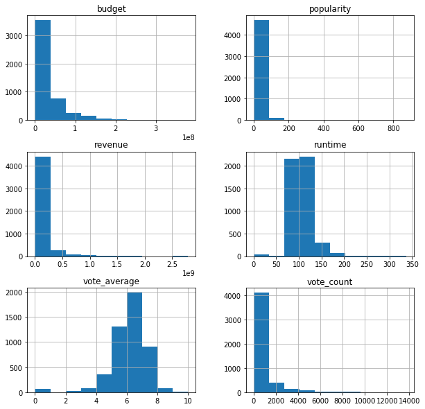

```python
df.hist(figsize = (10 , 10));
```

### Research Question 1

(What is the top three movie's that has the most revenues in the action genre)

```python
#First im going to select the movies that considers an action movie
# And then I'm going to view the top 3
mask_Action = df['genres'].str.contains('Action')
Top3_Rev_Action = df[mask_Action].nlargest(3,'revenue')
Top3_Rev_Action
```

|  | budget | genres | keywords | original_title | popularity | production_companies | release_date | revenue | runtime | spoken_languages | status | title | vote_average | vote_count |
| --- | --- | --- | --- | --- | --- | --- | --- | --- | --- | --- | --- | --- | --- | --- |
| 0 | 237000000 | [{"id": 28, "name": "Action"}, {"id": 12, "nam... | [{"id": 1463, "name": "culture clash"}, {"id":... | Avatar | 150.437577 | [{"name": "Ingenious Film Partners", "id": 289... | 2009-12-10 | 2787965087 | 162.0 | [{"iso_639_1": "en", "name": "English"}, {"iso... | Released | Avatar | 7.2 | 11800 |
| 16 | 220000000 | [{"id": 878, "name": "Science Fiction"}, {"id"... | [{"id": 242, "name": "new york"}, {"id": 5539,... | The Avengers | 144.448633 | [{"name": "Paramount Pictures", "id": 4}, {"na... | 2012-04-25 | 1519557910 | 143.0 | [{"iso_639_1": "en", "name": "English"}] | Released | The Avengers | 7.4 | 11776 |
| 28 | 150000000 | [{"id": 28, "name": "Action"}, {"id": 12, "nam... | [{"id": 1299, "name": "monster"}, {"id": 1718,... | Jurassic World | 418.708552 | [{"name": "Universal Studios", "id": 13}, {"na... | 2015-06-09 | 1513528810 | 124.0 | [{"iso_639_1": "en", "name": "English"}] | Released | Jurassic World | 6.5 | 8662 |

# Visualization

Showing top 3 movies that have the most revenues in the Action genre

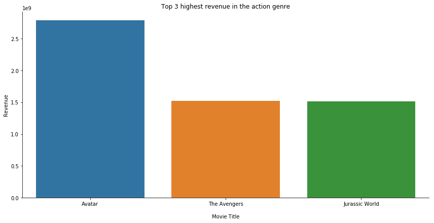

```python
sns.factorplot(x='original_title', y='revenue', size=6,aspect=2 ,kind='bar', data=Top3_Rev_Action)
plt.title('Top 3 highest revenue in the action genre')
plt.xlabel("\n Movie Title " )
plt.ylabel('Revenue')
plt.show()
```

### Research Question 2

(What is the differnce between movies that were released before 2010 and after in case of popularity)

```python
#First we're going to get the popularity mean of all movies that were released before 2010
Mask_Pop_Before = df.query('release_date <= "2009-12-31" ')['popularity'].mean()
Mask_Pop_Before
```

```
18.144620694278903
```

```python
#Second we're going to get the popularity mean of all movies that were released after 2010
Mask_Pop_After = df.query('release_date > "2009-12-31" ')['popularity'].mean()
Mask_Pop_After
```

```
29.316747509695297
```

Know since we know the mean of each mask we're going to know what's the diffrence between them

```python
#Substracting the mean of the movies that are released after 2010 from the movies that are released before 2010
diff_pop = Mask_Pop_After - Mask_Pop_Before
diff_pop
```

```
11.172126815416394
```

### Visualization

This will be much easier to understand with visualization

[figure not shown]

```python
plt.subplots(figsize=(10,6))
plt.bar(['Popularity after 2010','Popularity Before 2010','The difference between them'], [Mask_Pop_After , Mask_Pop_Before,diff_pop]  ,color = ['orange', 'pink','grey'])
plt.title("Visualization of The Two Masks sets")
plt.ylabel('Popularity')
plt.legend(loc = 'bottom')
plt.show()
```

After doing the analysis on this question seems that movies released after 2010 gained more popularity and by calculating the mean and difference I concluded that the differnece is 11 .

### Research Question 3

Does Walt Disney movies costs more than Columbia Pictures movies ?

To know if Walt Disney movies costs more than Columbia Pictures movies first we need to extract them from the dataframe

```python
#Extracting
Walt_Movies = df['production_companies'].str.contains('Walt Disney')
Colu_Movies = df['production_companies'].str.contains('Columbia Pictures')
```

We must get the mean of each set to know which costs more

```python
#Getting the mean of each sets above (Walt Disney and Columbia Pictures)
mean_Walt_Movies = df[Walt_Movies].budget.mean()
mean_Colu_Movies = df[Colu_Movies].budget.mean()
mean_Walt_Movies , mean_Colu_Movies
```

```
(82384474.977777779, 50392474.033444814)
```

## Visualization

After Viewing the mean we know that Walt disney costs more than Columbia Pictures but let's make a pie chart to visualize it much better

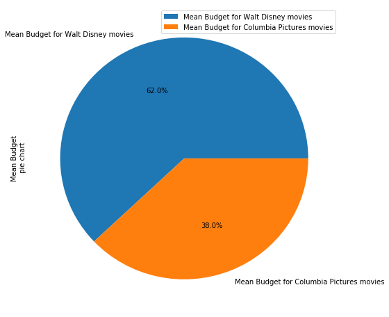

```python
#Plotting a pie chart for the budget of each dataset
#Creating a small data frame that contains the mean of the two production companies
mean_pie = pd.DataFrame([mean_Walt_Movies, mean_Colu_Movies],
                        index=['Mean Budget for Walt Disney movies',
                               'Mean Budget for Columbia Pictures movies'] ,
                        columns = ['Mean Budget\n pie chart'])
#now plot the pie chart
mean_pie.plot(kind='pie', subplots=True, figsize=(8, 8),autopct='%1.1f%%');
```

In this question and after getting the mean budget of each `Walt Disney` and `Columbia Pictures` I concluded that `Walt Disney` has the mean of `82.38m$` with `62%` and `Columbia Pictures` has the mean of `50.4m$` with `38%`.

#### Research Question 4

What is the correlation between `budget` and `revenue` since `2015`

to know the correlation between them we just need one scatter plot

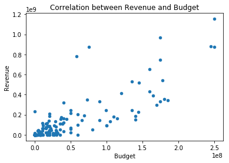

```python
m1 = df.query('release_date >= "2015-1-1"')[['budget' , 'revenue']]
m1.plot(x = 'budget' , y = 'revenue' , kind = 'scatter')
plt.title("Correlation between Revenue and Budget")
plt.xlabel('Budget')
plt.ylabel('Revenue')
plt.show()
```

as show in the graph above that the correlation between `budget` and `revenue` is moderately positive and there some outliers

## Conclusions

At the end there are problems in this data set which makes it hard to investigate in some cases , one of the problems are that the genre column contains a qoutaion marks which prevents you from performing the `.groupby()` function , overall the dataset has a lot of analysis to do and questions to ask .

# limitations are :

1. there missing values in the data set
2. some columns are hard to read (e.g `genres` and `keywords`)
3. some of the data are zeros
4. in Q4 I did my analysis on the movies that are released after 2015 to get a clear and viewable scatter plot
5. the data in this dataset was good enough to answers my questions but there are maybe another answers this data cannot answer

```python
from subprocess import call
call(['python', '-m', 'nbconvert', 'Investigate_a_Dataset.ipynb'])
```

```
0
```